# Relatório de Classificação

Lania Barros Gomes Martins

02 fevereiro, 2023

# 1 Contextualização

Será usada o dataset BreastCancer disponível no pacote “mlbench”. Na base constam 699 observações em 11 variáveis referentes a identificação de classes benígnas e malígnas. Foi observado 16 valores de atributos ausentes.

# 2 Objetivo

O objetivo é utilizar o conjunto **BreastCancer** para realizar análises de classificação. Para isso, a variável “Class”, onde constam as informações benign ou malignant, será utilizada como nossa variável dependente.

# 3 Extração e tratamento do dados

## 3.1 Carregamento dos pacotes

```r
library(devtools)
library(factoextra)
library(FactoMineR)
library(mlbench)
library(corrplot)
library(tree)
library(caret)
library(randomForest)
require(MASS)
```

## 3.2 Leitura e visualização do banco de dados

```r
data(BreastCancer)

dados<- BreastCancer[,-c(1)]
dados2<- BreastCancer[,-c(1)]

str(dados)
```

```
## 'data.frame':    699 obs. of  10 variables:
##  $ Cl.thickness   : Ord.factor w/ 10 levels "1"<"2"<"3"<"4"<..: 5 5 3 6 4 8 1 2 2 4 ...
##  $ Cell.size      : Ord.factor w/ 10 levels "1"<"2"<"3"<"4"<..: 1 4 1 8 1 10 1 1 1 2 ...
##  $ Cell.shape     : Ord.factor w/ 10 levels "1"<"2"<"3"<"4"<..: 1 4 1 8 1 10 1 2 1 1 ...
##  $ Marg.adhesion  : Ord.factor w/ 10 levels "1"<"2"<"3"<"4"<..: 1 5 1 1 3 8 1 1 1 1 ...
##  $ Epith.c.size   : Ord.factor w/ 10 levels "1"<"2"<"3"<"4"<..: 2 7 2 3 2 7 2 2 2 2 ...
##  $ Bare.nuclei    : Factor w/ 10 levels "1","2","3","4",..: 1 10 2 4 1 10 10 1 1 1 ...
##  $ Bl.cromatin    : Factor w/ 10 levels "1","2","3","4",..: 3 3 3 3 3 9 3 3 1 2 ...
##  $ Normal.nucleoli: Factor w/ 10 levels "1","2","3","4",..: 1 2 1 7 1 7 1 1 1 1 ...
##  $ Mitoses        : Factor w/ 9 levels "1","2","3","4",..: 1 1 1 1 1 1 1 1 5 1 ...
##  $ Class          : Factor w/ 2 levels "benign","malignant": 1 1 1 1 1 2 1 1 1 1 ...
```

```r
head(dados)
```

```
##   Cl.thickness Cell.size Cell.shape Marg.adhesion Epith.c.size Bare.nuclei
## 1            5         1          1             1            2           1
## 2            5         4          4             5            7          10
## 3            3         1          1             1            2           2
## 4            6         8          8             1            3           4
## 5            4         1          1             3            2           1
## 6            8        10         10             8            7          10
##   Bl.cromatin Normal.nucleoli Mitoses     Class
## 1           3               1       1    benign
## 2           3               2       1    benign
## 3           3               1       1    benign
## 4           3               7       1    benign
## 5           3               1       1    benign
## 6           9               7       1 malignant
```

## 3.3 Tratamento das variáveis

```r
for (i in 1:10){
  dados[,i] <- as.numeric(dados[,i])
}
```

## 3.4 Verificação de dados faltantes na base de dados

```r
any(is.na(dados))
```

```
## [1] TRUE
```

### 3.4.1 Percentual de dados faltantes

```r
NAS <- round(colSums(is.na(dados))*100/nrow(dados),2)
NAS[NAS>0]
```

```
## Bare.nuclei
##        2.29
```

Somente a coluna Bare.Nuclei apresenta dados NA.

### 3.4.2 Exclusão das observações com dados faltantes

Como eram poucos dados NA, optou-se por excluir essas linhas.

```r
df <- na.omit(dados)

dados2 <- na.omit(dados2)
```

A base passou de 699 para 683 observações.

### 3.4.3 Correlação entre variáveis

Verificação da existência de correlação entre as variáveis.

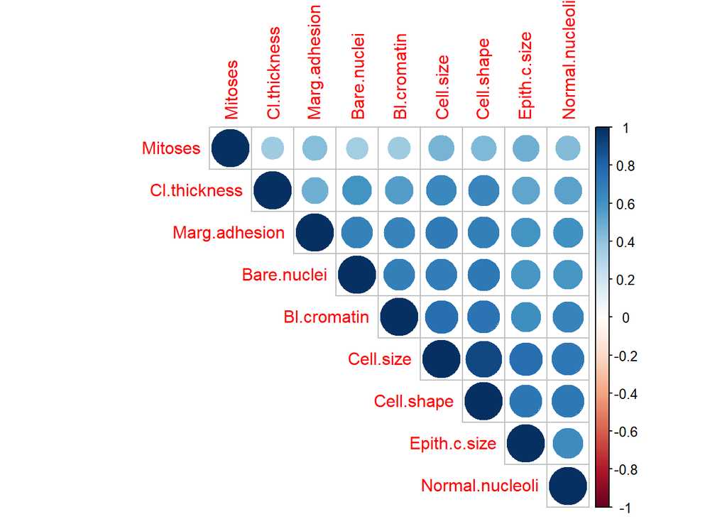

```r
#resultado=rcorr(as.matrix(df[,-10]))

corrplot(cor(df[,-10]), type="upper", order="hclust",
         sig.level = 0.01, insig = "blank")
```

# 4 Árvore de Classificação

## 4.1 Selecionar dados de treino

Seleção de parte dos dados para realização do treinamento.

```r
benigno <- dados2[dados2$Class=="benign",]
maligno <- dados2[dados2$Class=="malignant",]

dados_train <- rbind(benigno[1:222,],maligno[1:119,])
dados_test <- rbind(benigno[223:444,],maligno[119:239,])
```

## 4.2 Ajuste da árvore de classificação

```r
arvore1 <- tree(Class ~ ., data = dados_train)
```

```r
summary(arvore1)
```

```
##
## Classification tree:
## tree(formula = Class ~ ., data = dados_train)
## Variables actually used in tree construction:
## [1] "Cell.size"       "Bare.nuclei"     "Epith.c.size"    "Cl.thickness"
## [5] "Normal.nucleoli" "Marg.adhesion"
## Number of terminal nodes:  10
## Residual mean deviance:  0.08582 = 28.41 / 331
## Misclassification error rate: 0.0176 = 6 / 341
```

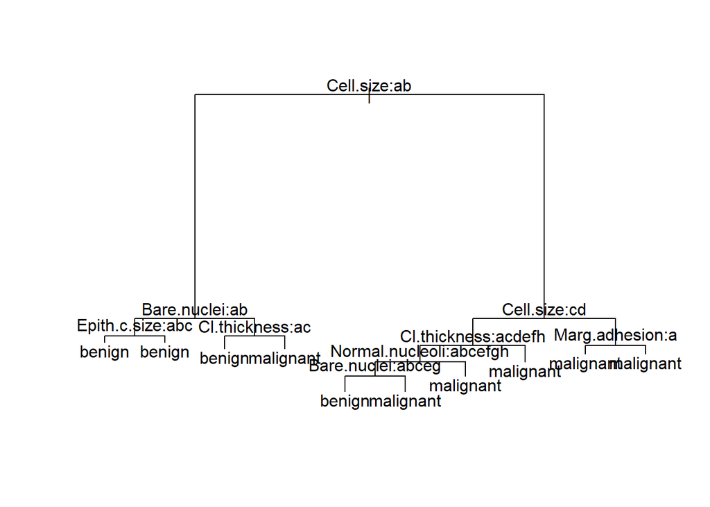

```r
plot(arvore1)
text(arvore1)
```

Para construção da árvore foi utilizada somente 6(seis) das 9(nove) variáveis do dataset.  
A árvore ficou com 10(dez) nós terminais.

## 4.3 Poda da árvore

Testes para verificar se é interessante a realização da poda.

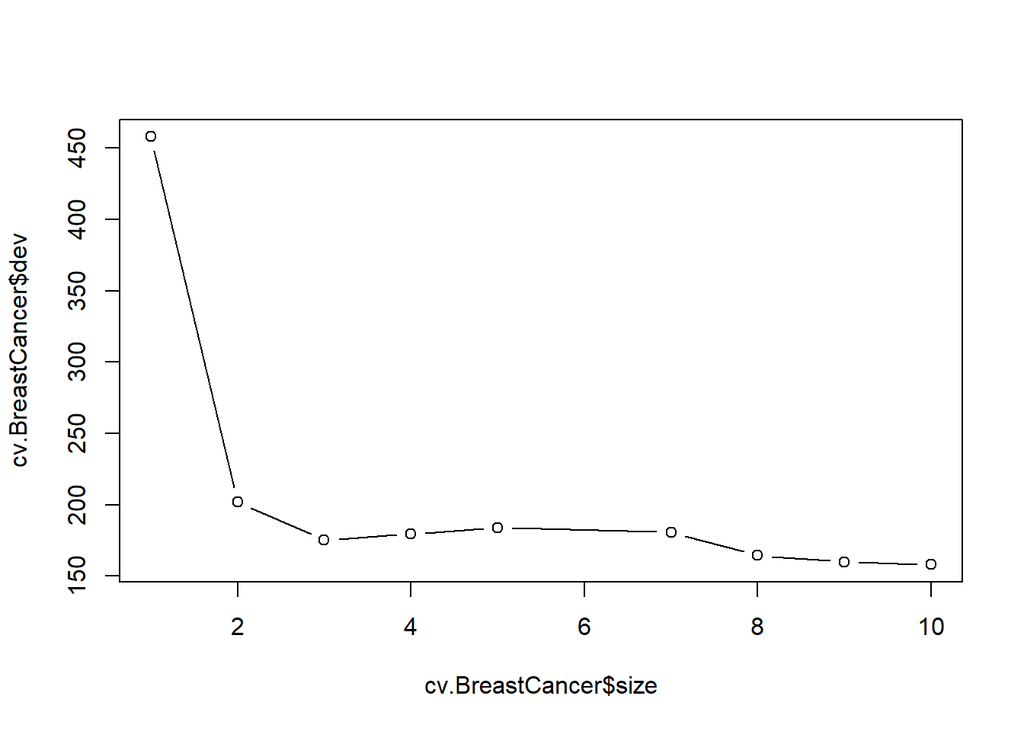

```r
cv.BreastCancer=cv.tree(arvore1)
plot(cv.BreastCancer$size ,cv.BreastCancer$dev,type="b")
```

Vamos estar realizando uma poda para 8(oito) nós terminais.

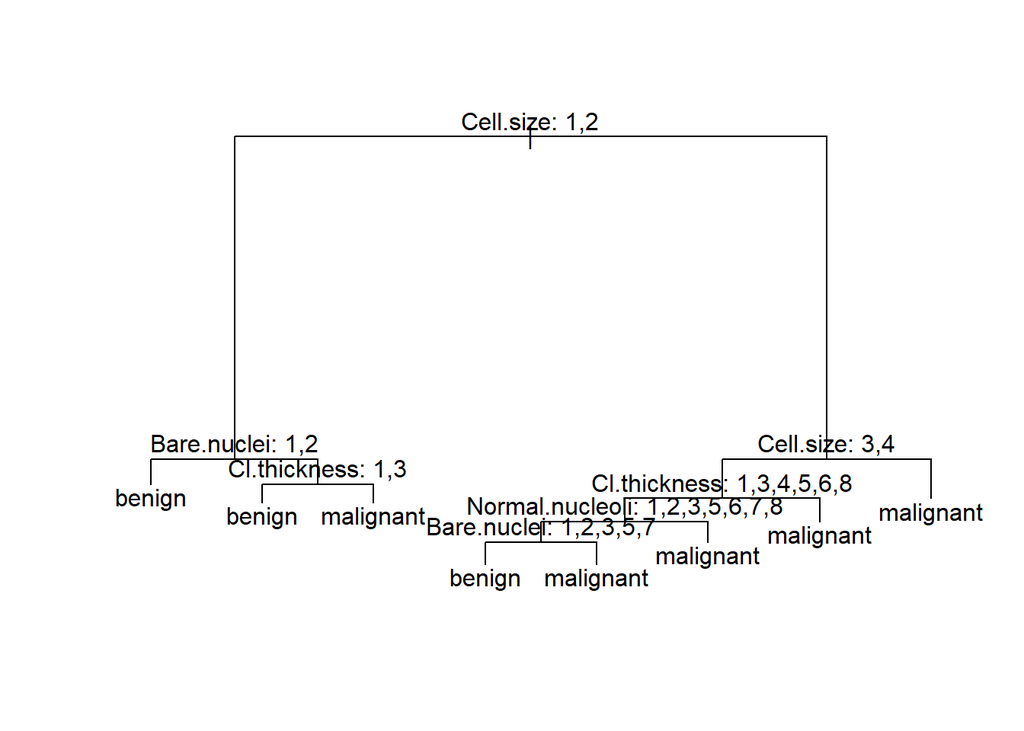

```r
mod_poda=prune.tree(arvore1,best=8)
plot(mod_poda)
text(mod_poda, pretty =0)
```

## 4.4 Teste de Predição

```r
pred_arv <- predict(mod_poda, dados_test, type="class")
head(pred_arv)
```

```
## [1] benign    benign    malignant benign    benign    benign
## Levels: benign malignant
```

```r
confusionMatrix(pred_arv, dados_test$Class)
```

```
## Confusion Matrix and Statistics
##
##            Reference
## Prediction  benign malignant
##   benign       214         8
##   malignant      8       113
##
##                Accuracy : 0.9534
##                  95% CI : (0.9254, 0.9731)
##     No Information Rate : 0.6472
##     P-Value [Acc > NIR] : <2e-16
##
##                   Kappa : 0.8978
##
##  Mcnemar's Test P-Value : 1
##
##             Sensitivity : 0.9640
##             Specificity : 0.9339
##          Pos Pred Value : 0.9640
##          Neg Pred Value : 0.9339
##              Prevalence : 0.6472
##          Detection Rate : 0.6239
##    Detection Prevalence : 0.6472
##       Balanced Accuracy : 0.9489
##
##        'Positive' Class : benign
##
```

Do total de 343 amostras, o modelo acertou 214 (benign) e 113 (malignant) com acurácia de 95%.

# 5 Random Forest

Realização de ajuste do modelo de árvore de classificação utilizando o random forest.

```r
rf<- randomForest(Class ~., data = dados_train,  mtry = 3)
rf
```

```
##
## Call:
##  randomForest(formula = Class ~ ., data = dados_train, mtry = 3)
##                Type of random forest: classification
##                      Number of trees: 500
## No. of variables tried at each split: 3
##
##         OOB estimate of  error rate: 4.11%
## Confusion matrix:
##           benign malignant class.error
## benign       213         9  0.04054054
## malignant      5       114  0.04201681
```

## 5.1 Avaliação do modelo (Predição)

```r
pred_rf <- predict(rf, dados_test)
confusionMatrix(pred_rf, dados_test$Class)
```

```
## Confusion Matrix and Statistics
##
##            Reference
## Prediction  benign malignant
##   benign       220         6
##   malignant      2       115
##
##                Accuracy : 0.9767
##                  95% CI : (0.9546, 0.9899)
##     No Information Rate : 0.6472
##     P-Value [Acc > NIR] : <2e-16
##
##                   Kappa : 0.9485
##
##  Mcnemar's Test P-Value : 0.2888
##
##             Sensitivity : 0.9910
##             Specificity : 0.9504
##          Pos Pred Value : 0.9735
##          Neg Pred Value : 0.9829
##              Prevalence : 0.6472
##          Detection Rate : 0.6414
##    Detection Prevalence : 0.6589
##       Balanced Accuracy : 0.9707
##
##        'Positive' Class : benign
##
```

Do total de 343 amostras o modelo acertou 220 (benign) e 115 (malignant) com acurácia de 97%

## 5.2 Verificação da importância de cada variável no ajuste

```r
i_mod_rf <-importance(rf)
i_mod_rf
```

```
##                 MeanDecreaseGini
## Cl.thickness           11.375215
## Cell.size              38.013881
## Cell.shape             35.586293
## Marg.adhesion           6.455151
## Epith.c.size           10.053622
## Bare.nuclei            25.345222
## Bl.cromatin            10.247082
## Normal.nucleoli        15.346835
## Mitoses                 1.937522
```

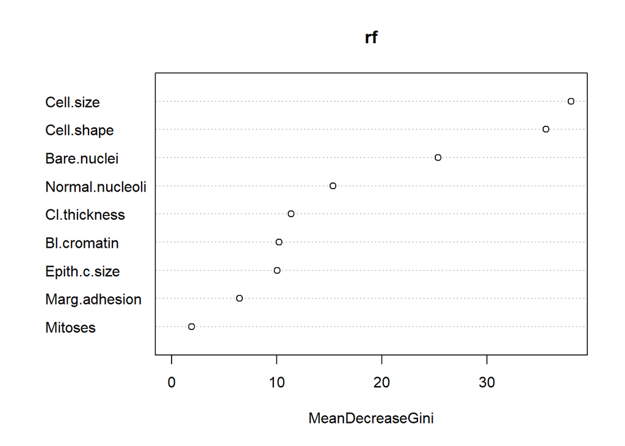

```r
varImpPlot (rf)
```

# 6 Validação cruzada

```r
r <- lda(formula = Class ~ .,
         data = dados_train,
         prior = c(1,1)/2, CV=TRUE)
```

## 6.1 Classifição e tabela de confusão

```r
classificao <- r$class


cvl <- table(dados_train$Class,classificao)
cvl
```

```
##            classificao
##             benign malignant
##   benign       214         8
##   malignant     13       106
```

## 6.2 Taxa de Erro Aparente

```r
TEA <- 1 - (sum(diag(cvl))/sum(cvl))
TEA
```

```
## [1] 0.06158358
```

# 7 Conclusão

Com base nos testes realizados podemos o observar que o modelo de árvore ajustado com o random forest obteve o melhor resultado, conforme observado abaixo:

[output not shown]

# 8 Referências

- [Infomações sobre o dataset utilizado] https://cran.r-project.org/web/packages/mlbench/mlbench.pdf